# RNAseq - Bioconductor

Carla Riera Segura

14 de Junio de 2020

## Resumen

En este documento se presenta un análisis de datos de RNA-seq utilizando la herramienta R/Bioconductor. El flujo de trabajo comienza con dos ficheros preprocesados, *counts.csv* (contajes) y *targets.csv* (grupos y covariables), los cuales se preparan para proceder a realizar el análisis de expresión diferencial. Posteriormente, se sigue el flujo detallado en la web de Bioconductor: http://master.bioconductor.org/packages/release/workflows/vignettes/rnaseqGene/inst/doc/rnaseqGene.html#aligning-reads-to-a-reference-genome. Los datos y el código para el análisis se pueden visualizar en un repositorio de github[^1].

## Objetivos

El objetivo de este estudio fue estudiar la expresión y regulación de genes específicos de tejido. Para ello se recolectaron datos de expresión (RNA-seq) pertencientes a un análisis de tiroides en donde se compara tres tipos de infiltración medidos en un total de 292 muestras pertenecientes a tres grupos: *not infiltrated tissues* (NIT), *small focal infiltrates* (SFI) y *extensive lymphoid infiltrates* (ELI). Así pues, se realizaron tres comparaciones NIT-SFI, NIT-ELI y SFI-ELI.

## Materiales

Los datos utilizados se cargaron de un estudio obtenido del repositorio *Genotype-Tissue Expression* (GTEx), en el cual se recolectaron muestras de 54 sitios de tejido no diseminado en casi 1000 individuos. Los datos fueron proporcionados a través de dos ficheros: *counts.csv* correspondiente a los contajes y *targets.csv* a los grupos y covariables.

## Métodos

### Preparación de los datos

Para empezar con el estudio vamos a cargar los dos ficheros proporcionados, sobre los que debemos realizar alguna pequeña modificación para evitar errores durante el análisis.

```r
# Carga de los archivos targets y counts
targets <- read.csv("~/Desktop/Datos omicos/PEC 2/RNA-seq/Materials/targets.csv", header=TRUE, sep=",")
counts <- read.csv("~/Desktop/Datos omicos/PEC 2/RNA-seq/Materials/counts.csv", header=TRUE, row.names=1, sep=";")
```

La variable correspondiente al nombre de las muestras está presentada en un formato diferente (en el archivo *targets* la separación es mediante guiones y en el archivo *counts* mediante puntos). Así pues, es necesario la conversión al mismo formato para evitar errores posteriores. Para ello se ha decidido mantener el formato del archivo *counts*, sustituyendo los guiones por puntos en el archivo *targets*. Además, definiremos la variable *Group* como factor.

```r
# Sustitución de - por . en la variable Sample_Name del archivo targets
targets$Sample_Name <- gsub("[-]", ".", targets$Sample_Name)

# Definición de la variable Group como factor
targets$Group <- factor(targets$Group)
```

El archivo *counts* presenta el código ENSEMBL incluyendo la versión. Dicho parámetro debe ser eliminado para evitar errores durante el análisis.

```r
# Eliminación de la versión del código ENSEMBL del archivo counts
rownames(counts) <- gsub("\\..*", "", rownames(counts), fixed = FALSE)
```

Una vez realizados estos cambios, debemos seleccionar 30 muestras aleatoriamente, 10 de cada grupo. Para ello, primero dividiremos los datos del archivo *targets* en tres variables distintas según el grupo al que pertenecen. Posteriormente, fijaremos una semilla para que siempre se trabaje con las mismas muestras y extraeremos 10 muestras de cada grupo aleatoriamente con ayuda del comando *sample()* creando un dataset para cada grupo. Finalmente, para limpiar los datos, adjudicaremos como nombre de filas la variable *Sample_Name* y eliminaremos la duplicación.

```r
# Carga de las librerías necesarias
library("dplyr")

# División de las muestras en tres variables según la variable Group
NIT_all <- subset(targets, targets$Group=="NIT")
SFI_all <- subset(targets, targets$Group=="SFI")
ELI_all <- subset(targets, targets$Group=="ELI")

# Fijación de la semilla
set.seed(12345)

# Extracción aleatoria de 10 muestras de cada grupo
n <- 10
NIT <- sample(1:nrow(NIT_all), size=n, replace=FALSE)
NIT <- NIT_all[NIT, ]
SFI <- sample(1:nrow(SFI_all), size=n, replace=FALSE)
SFI <- SFI_all[SFI, ]
ELI <- sample(1:nrow(ELI_all), size=n, replace=FALSE)
ELI <- ELI_all[ELI, ]

# Ajudicación de Sample_Name como nombre de filas y eliminación de la duplicación
rownames(NIT) <- NIT$Sample_Name
NIT <- select(NIT, -Sample_Name)
rownames(SFI) <- SFI$Sample_Name
SFI <- select(SFI, -Sample_Name)
rownames(ELI) <- ELI$Sample_Name
ELI <- select(ELI, -Sample_Name)
```

Para acabar este apartado, vamos a crear las variables colData y countData de cada comparación (NITvsSFI, NITvsELI y SFIvsELI). Para ello, uniremos en una variable los grupos a comparar creando la variable colData y subsatearemos las columnas escogidas en el archivo *counts* a partir de la información de las filas de la variable colData creando la variable countData.

```r
# Comparación NITvsSFI
colData_NIT_SFI <- rbind(NIT,SFI)
countData_NIT_SFI <- counts[,rownames(colData_NIT_SFI)]

# Comparación NITvsELI
colData_NIT_ELI <- rbind(NIT,ELI)
countData_NIT_ELI <- counts[,rownames(colData_NIT_ELI)]

# Comparación SFIvsELI
colData_SFI_ELI <- rbind(SFI,ELI)
countData_SFI_ELI <- counts[,rownames(colData_SFI_ELI)]
```

### Comparación NITvsSFI

#### Creación del objeto DESeqDataSet

Vamos a construir el *DESeqDataSet* a partir de la matriz de conteo (countData) y la tabla de información de la muestra (colData) utilizando el comando *DESeqDataSetFromMatrix()* del paquete *DESeq2*.

```r
# Carga de las librerías necesarias
library("DESeq2")

# Creación del objeto DESeqDataSet
ddsMat_NIT_SFI <- DESeqDataSetFromMatrix(countData = countData_NIT_SFI, colData = colData_NIT_SFI, design = ~ Group)
```

#### Análisis exploratorio y visualización

##### Prefiltrado del conjunto de datos

La matriz de conteo con el *DESeqDataSet* contiene muchas filas con solo ceros y también muchas filas con solo unos pocos fragmentos en total. Con el fin de reducir el tamaño del objeto y aumentar la velocidad de nuestras funciones, vamos a eliminar las filas que tienen poca información sobre la cantidad de expresión génica. Para ello aplicamos la regla de filtrado más mínima que consiste en eliminar las filas del *DESeqDataSet* que no tienen recuentos, o que solamente tienen un único recuento en todas las muestras.

```r
# Número de filas iniciales
nrow(ddsMat_NIT_SFI)
```

```
## [1] 56202
```

```r
# Aplicación de filtrado mínimo
ddsMat_NIT_SFI_filtered <- ddsMat_NIT_SFI[rowSums(counts(ddsMat_NIT_SFI)) > 1,]

# Número de filas mantenidas después del filtrado
nrow(ddsMat_NIT_SFI_filtered)
```

```
## [1] 41692
```

Podemos observar que el tamaño del objeto ha disminuido.

##### Transformación de logaritmo regularizado o rlog

El paquete *DESeq2* ofrece la transformación rlog, la cual estabiliza la varianza a través de la media. Dicha transformación, a pesar de ser más sensible a los valores atípicos de conteo alto que VST (*Variance Stabilizing Transformation*), tiende a funcionar bien en conjuntos de datos pequeños (n<30) como es nuestro caso, donde tenemos un conjunto de datos de 20 muestras.

Así pues, vamos a aplicar dicha transformación a los datos de conteo, obteniendo un objeto DESeqTransform que se basa en la clase SummarizedExperiment.

```r
# Aplicación de la transformación rlog
rld <- rlog(ddsMat_NIT_SFI_filtered, blind = FALSE)

# Visualización de las 3 primera filas de los datos transformados con rlog
head(assay(rld), 3)
```

```
##                 GTEX.QEL4.0726.SM.3GIJ5 GTEX.132AR.1126.SM.5P9GA
## ENSG00000223972               1.4634911                0.9906898
## ENSG00000227232               9.3465763                9.3762053
## ENSG00000243485               0.6947987                0.5262871
##                 GTEX.ZDYS.0626.SM.5J2N5 GTEX.ZTPG.0826.SM.5DUVC
## ENSG00000223972               1.4087038               1.1276459
## ENSG00000227232               9.1504614               9.2115540
## ENSG00000243485               0.6992131               0.5655894
##                 GTEX.ZTX8.0626.SM.59HKC GTEX.RU1J.0226.SM.2TF5Y
## ENSG00000223972               1.2829308               1.6707340
## ENSG00000227232               9.1433946               9.7382041
## ENSG00000243485               0.4483178               0.6638533
##                 GTEX.139T6.0326.SM.5J2LY GTEX.13S86.1126.SM.5RQJX
## ENSG00000223972                1.0728586                1.1572834
## ENSG00000227232                8.9588203                9.8648846
## ENSG00000243485                0.7228847                0.7046882
##                 GTEX.13NZA.1026.SM.5MR48 GTEX.13VXU.0826.SM.5KLZ2
## ENSG00000223972                1.1023090                1.0911539
## ENSG00000227232                9.5653698                8.7560865
## ENSG00000243485                0.4478278                0.4451802
##                 GTEX.OXRP.0326.SM.33HBJ GTEX.11DXY.0426.SM.5H12R
## ENSG00000223972               1.2001409                1.0024796
## ENSG00000227232               9.4890611                9.3093971
## ENSG00000243485               0.6991245                0.4495606
##                 GTEX.13NZ8.0226.SM.5J2OK GTEX.12WSG.0226.SM.5EGIF
## ENSG00000223972                1.0898533                1.3651318
## ENSG00000227232                9.7226910                9.0051155
## ENSG00000243485                0.6155536                0.5822103
##                 GTEX.Y5V6.0526.SM.4VBRV GTEX.RM2N.0526.SM.2TF4N
## ENSG00000223972               1.2509940               1.3156096
## ENSG00000227232               8.8157969               8.9132503
## ENSG00000243485               0.6865196               0.8252159
##                 GTEX.12BJ1.0426.SM.5FQSO GTEX.139UW.0126.SM.5KM1B
## ENSG00000223972                1.1229880                1.2361418
## ENSG00000227232                8.9342054                9.0318560
## ENSG00000243485                0.6592959                0.4544756
##                 GTEX.SIU8.0626.SM.2XCDN GTEX.XMK1.0626.SM.4B65A
## ENSG00000223972               1.2381836               1.6875055
## ENSG00000227232               9.3768904               9.1373731
## ENSG00000243485               0.6041438               0.5488466
```

A continuación se muestra el efecto de la transformación a través de un diagrama de dispersión de recuentos transformados de dos muestras (primera contra segunda).

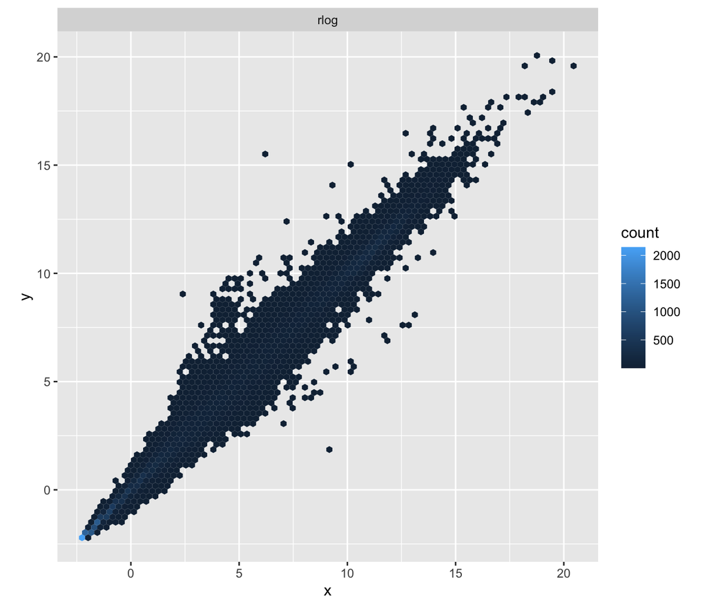

```r
# Carga de las librerías necesarias
library("dplyr")
library("ggplot2")

# Representación del gráfico de dispersión de recuentos transformados
ddsMat_NIT_SFI_filtered <- estimateSizeFactors(ddsMat_NIT_SFI_filtered)

df <- bind_rows(as_data_frame(assay(rld)[, 1:2]) %>% mutate(transformation = "rlog"))
colnames(df)[1:2] <- c("x", "y")

ggplot(df, aes(x = x, y = y)) + geom_hex(bins = 80) +
  coord_fixed() + facet_grid( . ~ transformation)
```

Podemos ver como rlog comprime las diferencias para los genes de recuento bajo (esquina inferior izquierda), para los cuales los datos proporcionan poca información sobre la expresión diferencial.

##### Distancia de muestras

Con el fin de evaluar la similitud general entre muestras, utilizamos la función *dist()* para calcular la distancia euclidiana entre ellas.

```r
# Cálculo de la distancia euclidiana entre muestras
sampleDists <- dist(t(assay(rld)))
head(sampleDists)
```

```
## [1] 108.65184 110.40209  99.57864  90.18654  91.37747  94.50603
```

Procedemos a visualizar las distancias en un mapa de calor con ayuda de la función *pheatmap()*, proporcionando como argumento *clustering_distance* la matriz de distancias *sampleDists*.

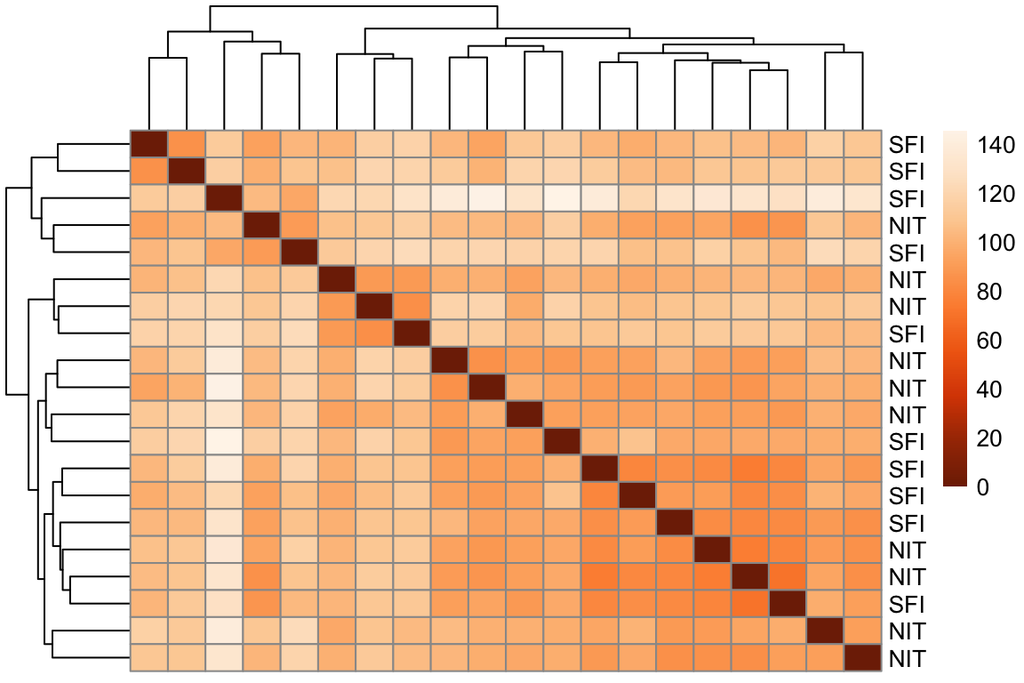

```r
# Carga de las librerías necesarias
library("pheatmap")
library("RColorBrewer")

# Definicón de sampleDists como matriz
sampleDistMatrix <- as.matrix(sampleDists)
rownames(sampleDistMatrix) <- paste(rld$Group, sep="-")
colnames(sampleDistMatrix) <- NULL

# Visualización del mapa de calor
colors <- colorRampPalette(rev(brewer.pal(9,"Oranges")))(255)
pheatmap(sampleDistMatrix,
         clustering_distance_rows = sampleDists,
         clustering_distance_cols = sampleDists,
         col = colors)
```

##### Gráfico PCA

Ahora vamos a visualizar de otra forma las distancias muestra a muestra a través de un análisis de componentes principales (PCA) utilizando los datos rlog. La variable *Group* se especifica por *intgroup* ya que es el grupo interesante para etiquetar las muestras.

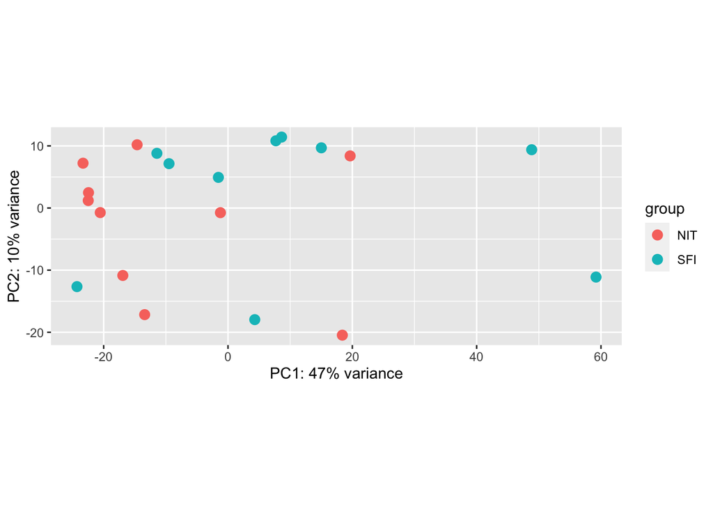

```r
# Visualización del gráfico PCA utilizando los datos rlog
plotPCA(rld, intgroup = c("Group"))
```

#### Análisis de expresión diferencial

##### Ejecución de la canalización de expresión diferencial

Vamos a ejecutar la canalización de expresión diferencial en los recuentos sin procesar con la función *DESeq()*.

```r
# Canalización de expresión diferencial
ddsMat_NIT_SFI <- DESeq(ddsMat_NIT_SFI, parallel =TRUE)
```

```
## -- replacing outliers and refitting for 508 genes
## -- DESeq argument 'minReplicatesForReplace' = 7
## -- original counts are preserved in counts(dds)
```

Dicha función devuelve un DESeqDataSet que contiene todos los parámetros ajustados dentro de él.

##### Creación de la tabla de resultados

```r
# Creación de la tabla de resultados
res <- results(ddsMat_NIT_SFI, contrast=c("Group","NIT","SFI"))
res
```

```
## log2 fold change (MLE): Group NIT vs SFI
## Wald test p-value: Group NIT vs SFI
## DataFrame with 56202 rows and 6 columns
##                          baseMean     log2FoldChange             lfcSE
##                         <numeric>          <numeric>         <numeric>
## ENSG00000223972  2.67209284224698 -0.141084893978263 0.680400109190209
## ENSG00000227232  632.754468983441    0.2106452921849 0.209356219146725
## ENSG00000243485  1.59997582137021 -0.255332227520192 0.744776516687726
## ENSG00000237613  1.84109856685849  0.623355731034559 0.712611915899569
## ENSG00000268020 0.926936466461697  0.390601216088091  1.12875371590097
## ...                           ...                ...               ...
## ENSG00000198695  72330.7912290681  0.254920427032111 0.522249321668874
## ENSG00000210194  33.2687528101505 0.0942399558616333 0.667054473346449
## ENSG00000198727  432800.916314286  0.464576388890082 0.249037843582158
## ENSG00000210195 0.765988268741835  0.857258052618085   1.1280581807915
## ENSG00000210196  2.07421737999434    0.8350253306857 0.800251074424298
##                               stat             pvalue              padj
##                          <numeric>          <numeric>         <numeric>
## ENSG00000223972 -0.207355777979193  0.835732016060047 0.993444213449456
## ENSG00000227232   1.00615731905853  0.314339899631606 0.993444213449456
## ENSG00000243485 -0.342830663694582  0.731725856097775 0.993444213449456
## ENSG00000237613  0.874747835570027  0.381711126028597 0.993444213449456
## ENSG00000268020  0.346046449801775  0.729307806780094 0.993444213449456
## ...                            ...                ...               ...
## ENSG00000198695  0.488120168768244  0.625464725969498 0.993444213449456
## ENSG00000210194  0.141277751109073  0.887650525354744 0.993444213449456
## ENSG00000198727   1.86548510944208 0.0621134374803082 0.993444213449456
## ENSG00000210195   0.75994134630236  0.447289645600063 0.993444213449456
## ENSG00000210196   1.04345418253442  0.296737990370958 0.993444213449456
```

Vamos a mostrar la información sobre el significado de las columnas del objeto *res*.

```r
# Información sobre las columnas del objeto res
mcols(res, use.names = TRUE)
```

```
## DataFrame with 6 rows and 2 columns
##                        type                               description
##                 <character>                               <character>
## baseMean       intermediate mean of normalized counts for all samples
## log2FoldChange      results  log2 fold change (MLE): Group NIT vs SFI
## lfcSE               results          standard error: Group NIT vs SFI
## stat                results          Wald statistic: Group NIT vs SFI
## pvalue              results       Wald test p-value: Group NIT vs SFI
## padj                results                      BH adjusted p-values
```

Finalmente, mostramos un resumen de la variable *res*.

```r
# Visualización resumen de res
summary(res)
```

```
##
## out of 44682 with nonzero total read count
## adjusted p-value < 0.1
## LFC > 0 (up)       : 0, 0%
## LFC < 0 (down)     : 0, 0%
## outliers [1]       : 0, 0%
## low counts [2]     : 4, 0.009%
## (mean count < 0)
## [1] see 'cooksCutoff' argument of ?results
## [2] see 'independentFiltering' argument of ?results
```

#### Análisis de los resultados

##### Gráficación de los resultados

Vamos a visualizar los recuentos de un gen en particular con la función *plotCounts()* tomando como argumentos el DESeqDataSetFromMatrix, un nombre de gen y el grupo sobre el que trazar los recuentos.

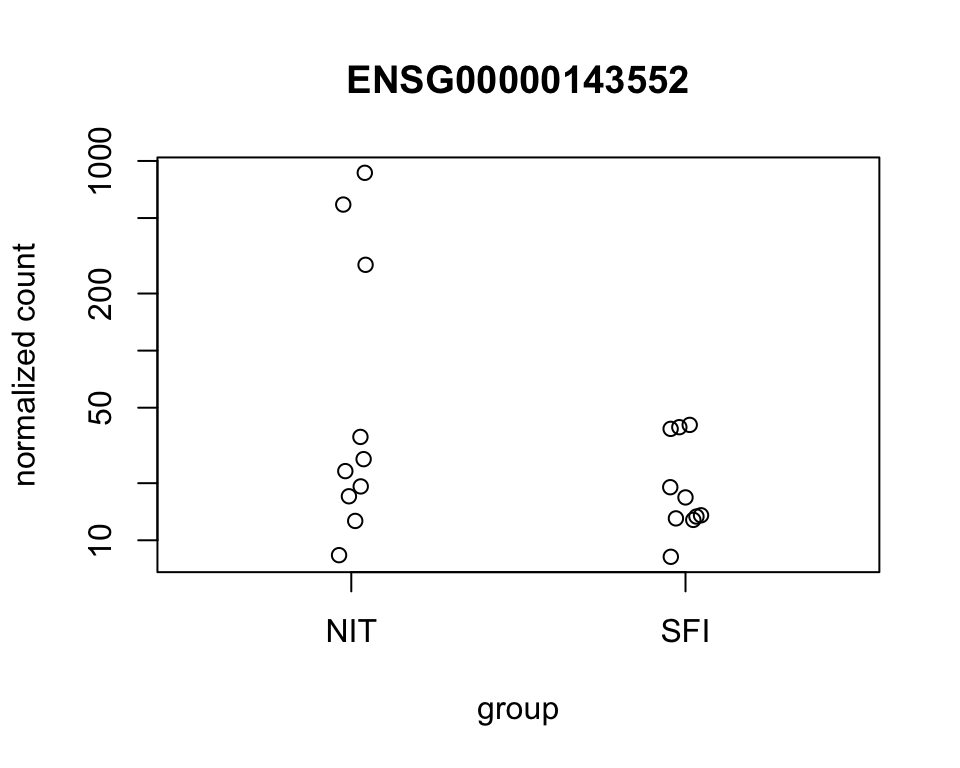

```r
# Selección del gen a mostrar
topGene <- rownames(res)[which.min(res$padj)]

# Representación del gráfico de los recuentos del gen
plotCounts(ddsMat_NIT_SFI, gene=topGene, intgroup=c("Group"))
```

##### Anotación y exportación de los resultados

La tabla de resultados obtenida hasta ahora, únicamente contiene los ID de los genes ENSEMBL. Para agregar más columnas informativas vamos a cargar los paquetes de anotación de Bioconductor para mapear varios esquemas de identificación entre sí.

```r
# Carga de las librerías necesarias
library("AnnotationDbi")
library("org.Hs.eg.db")

# Visualización de la lista de claves disponibles
columns(org.Hs.eg.db)
```

```
##  [1] "ACCNUM"       "ALIAS"        "ENSEMBL"      "ENSEMBLPROT"  "ENSEMBLTRANS"
##  [6] "ENTREZID"     "ENZYME"       "EVIDENCE"     "EVIDENCEALL"  "GENENAME"
## [11] "GO"           "GOALL"        "IPI"          "MAP"          "OMIM"
## [16] "ONTOLOGY"     "ONTOLOGYALL"  "PATH"         "PFAM"         "PMID"
## [21] "PROSITE"      "REFSEQ"       "SYMBOL"       "UCSCKG"       "UNIGENE"
## [26] "UNIPROT"
```

Con la función *mapIds* procedemos a agregar columnas a nuestra tabla de resultados. En concreto, vamos a añadir el símbolo del gen y la identificación de Entrez.

```r
# Agregación columna símbolo del gen
res$symbol <- mapIds(org.Hs.eg.db,
                     keys=row.names(res),
                     column="SYMBOL",
                     keytype="ENSEMBL",
                     multiVals="first")
# Agregación columna identificación de Entrez
res$entrez <- mapIds(org.Hs.eg.db,
                     keys=row.names(res),
                     column="ENTREZID",
                     keytype="ENSEMBL",
                     multiVals="first")
# Visualización de la nueva tabla de resultados ordenada por el p-valor
resOrdered <- res[order(res$pvalue),]
head(resOrdered, 3)
```

```
## log2 fold change (MLE): Group NIT vs SFI
## Wald test p-value: Group NIT vs SFI
## DataFrame with 3 rows and 8 columns
##                         baseMean    log2FoldChange             lfcSE
##                        <numeric>         <numeric>         <numeric>
## ENSG00000241294 187.192801551326 -5.57859546205175  1.24595203454928
## ENSG00000147724 14.3197874480727 -1.52329338649514 0.351057396004131
## ENSG00000088340 755.155275782652 -3.06450668419771 0.707875458200049
##                              stat               pvalue              padj
##                         <numeric>            <numeric>         <numeric>
## ENSG00000241294   -4.477375779614 7.55661700838367e-06 0.203354506161198
## ENSG00000147724 -4.33915765294747 1.43029891455894e-05 0.203354506161198
## ENSG00000088340 -4.32916079897725 1.49678618521622e-05 0.203354506161198
##                      symbol      entrez
##                 <character> <character>
## ENSG00000241294          NA          NA
## ENSG00000147724     FAM135B       51059
## ENSG00000088340      FER1L4       80307
```

Vamos a exportar la tabla de resultados en un archivo *.csv*.

```r
# Exportación de los resultados en fichero .csv
resOrderedDF <- as.data.frame(resOrdered)
write.csv(resOrderedDF, "./Results/results_NIT_SFI.csv")
```

Para obtener un fichero más sofisticado de los resultados, vamos a utilizar el paquete *ReportingTools* para generar automáticamente un documento HTML dinámico.

```r
# Carga de las librerías necesarias
library("ReportingTools")

# Creación del fichero HTML
htmlRep <- HTMLReport(shortName="Report_NIT_SFI", title="Report_NIT_SFI", reportDirectory="./Reports")
publish(resOrderedDF, htmlRep)
url <- finish(htmlRep)
browseURL(url)
```

### Comparación NITvsELI

#### Creación del objeto DESeqDataSet

Vamos a construir el *DESeqDataSet* a partir de la matriz de conteo (countData) y la tabla de información de la muestra (colData) utilizando el comando *DESeqDataSetFromMatrix()* del paquete *DESeq2*.

```r
# Carga de las librerías necesarias
library("DESeq2")

# Creación del objeto DESeqDataSet
ddsMat_NIT_ELI <- DESeqDataSetFromMatrix(countData = countData_NIT_ELI, colData = colData_NIT_ELI, design = ~ Group)
```

#### Análisis exploratorio y visualización

##### Prefiltrado del conjunto de datos

La matriz de conteo con el *DESeqDataSet* contiene muchas filas con solo ceros y también muchas filas con solo unos pocos fragmentos en total. Con el fin de reducir el tamaño del objeto y aumentar la velocidad de nuestras funciones, vamos a eliminar las filas que tienen poca información sobre la cantidad de expresión génica. Para ello aplicamos la regla de filtrado más mínima que consiste en eliminar las filas del *DESeqDataSet* que no tienen recuentos, o que solamente tienen un único recuento en todas las muestras.

```r
# Número de filas iniciales
nrow(ddsMat_NIT_ELI)
```

```
## [1] 56202
```

```r
# Aplicación de filtrado mínimo
ddsMat_NIT_ELI_filtered <- ddsMat_NIT_ELI[rowSums(counts(ddsMat_NIT_ELI)) > 1,]

# Número de filas mantenidas después del filtrado
nrow(ddsMat_NIT_ELI_filtered)
```

```
## [1] 41500
```

Podemos observar que el tamaño del objeto ha disminuido.

##### Transformación de logaritmo regularizado o rlog

El paquete *DESeq2* ofrece la transformación rlog, la cual estabiliza la varianza a través de la media. Dicha transformación, a pesar de ser más sensible a los valores atípicos de conteo alto que VST (*Variance Stabilizing Transformation*), tiende a funcionar bien en conjuntos de datos pequeños (n<30) como es nuestro caso, donde tenemos un conjunto de datos de 20 muestras.

Así pues, vamos a aplicar dicha transformación a los datos de conteo, obteniendo un objeto DESeqTransform que se basa en la clase SummarizedExperiment.

```r
# Aplicación de la transformación rlog
rld <- rlog(ddsMat_NIT_ELI_filtered, blind = FALSE)

# Visualización de las 3 primera filas de los datos transformados con rlog
head(assay(rld), 3)
```

```
##                 GTEX.QEL4.0726.SM.3GIJ5 GTEX.132AR.1126.SM.5P9GA
## ENSG00000223972               1.2811448                0.6136028
## ENSG00000227232               9.3225584                9.3691526
## ENSG00000243485               0.2974392                0.0709680
##                 GTEX.ZDYS.0626.SM.5J2N5 GTEX.ZTPG.0826.SM.5DUVC
## ENSG00000223972               1.2168702               0.8213218
## ENSG00000227232               9.1263167               9.1961212
## ENSG00000243485               0.3102303               0.1240743
##                 GTEX.ZTX8.0626.SM.59HKC GTEX.RU1J.0226.SM.2TF5Y
## ENSG00000223972                1.042234               1.5478733
## ENSG00000227232                9.110331               9.7492351
## ENSG00000243485               -0.045447               0.2505911
##                 GTEX.139T6.0326.SM.5J2LY GTEX.13S86.1126.SM.5RQJX
## ENSG00000223972                0.7413482                0.8620753
## ENSG00000227232                8.9180181                9.8865024
## ENSG00000243485                0.3427202                0.3134426
##                 GTEX.13NZA.1026.SM.5MR48 GTEX.13VXU.0826.SM.5KLZ2
## ENSG00000223972               0.78410082               0.76804629
## ENSG00000227232               9.56677391               8.69865645
## ENSG00000243485              -0.04583603              -0.04906157
##                 GTEX.111VG.0526.SM.5N9BW GTEX.YFC4.2626.SM.5P9FQ
## ENSG00000223972                0.8083133              0.71001717
## ENSG00000227232                9.0149947              9.59235816
## ENSG00000243485                0.1139125              0.03894367
##                 GTEX.13NZ9.1126.SM.5MR37 GTEX.14BMU.0226.SM.5S2QA
## ENSG00000223972               0.61118953               0.98424168
## ENSG00000227232               9.43827107               9.00807594
## ENSG00000243485               0.06653558              -0.03669537
##                 GTEX.R55G.0726.SM.2TC6J GTEX.11XUK.0226.SM.5EQLW
## ENSG00000223972               1.5170797               0.63706176
## ENSG00000227232               8.8645066               8.88754298
## ENSG00000243485               0.2920842              -0.04079205
##                 GTEX.ZYY3.1926.SM.5GZXS GTEX.14ABY.0926.SM.5Q5DY
## ENSG00000223972               1.4082956                0.7608946
## ENSG00000227232               9.8741769                9.2536516
## ENSG00000243485               0.1194347                0.1894990
##                 GTEX.13QJC.0826.SM.5RQKC GTEX.YJ89.0726.SM.5P9F7
## ENSG00000223972                0.6370672              1.01671016
## ENSG00000227232                9.6187695              9.58675438
## ENSG00000243485                0.1143405              0.04977771
```

A continuación se muestra el efecto de la transformación a través de un diagrama de dispersión de recuentos transformados de dos muestras (primera contra segunda).

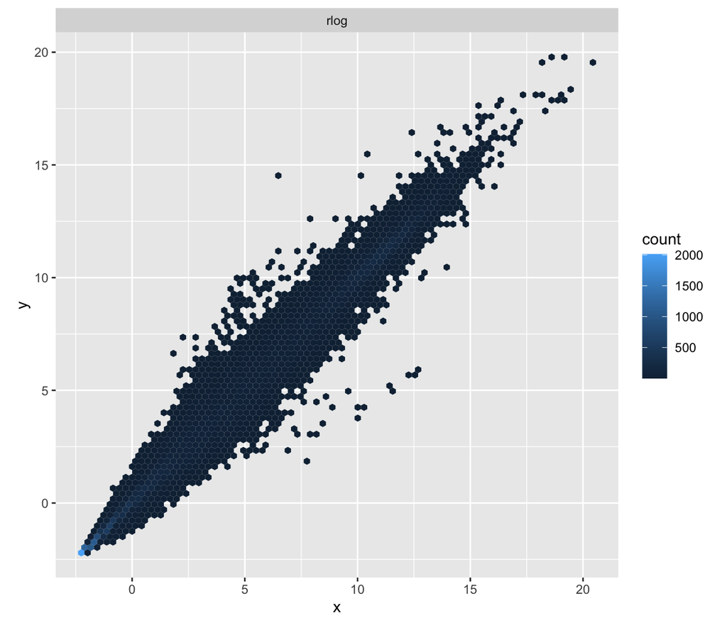

```r
# Carga de las librerías necesarias
library("dplyr")
library("ggplot2")

# Representación del gráfico de dispersión de recuentos transformados
ddsMat_NIT_ELI_filtered <- estimateSizeFactors(ddsMat_NIT_ELI_filtered)

df <- bind_rows(as_data_frame(assay(rld)[, 1:2]) %>% mutate(transformation = "rlog"))

colnames(df)[1:2] <- c("x", "y")

ggplot(df, aes(x = x, y = y)) + geom_hex(bins = 80) +
  coord_fixed() + facet_grid( . ~ transformation)
```

Podemos ver como rlog comprime las diferencias para los genes de recuento bajo (esquina inferior izquierda), para los cuales los datos proporcionan poca información sobre la expresión diferencial.

##### Distancia de muestras

Con el fin de evaluar la similitud general entre muestras, utilizamos la función *dist()* para calcular la distancia euclidiana entre ellas.

```r
# Cálculo de la distancia euclidiana entre muestras
sampleDists <- dist(t(assay(rld)))
head(sampleDists)
```

```
## [1] 122.4094 123.7812 113.9170 103.8510 106.7124 108.2723
```

Procedemos a visualizar las distancias en un mapa de calor con ayuda de la función *pheatmap()*, proporcionando como argumento *clustering_distance* la matriz de distancias *sampleDists*.

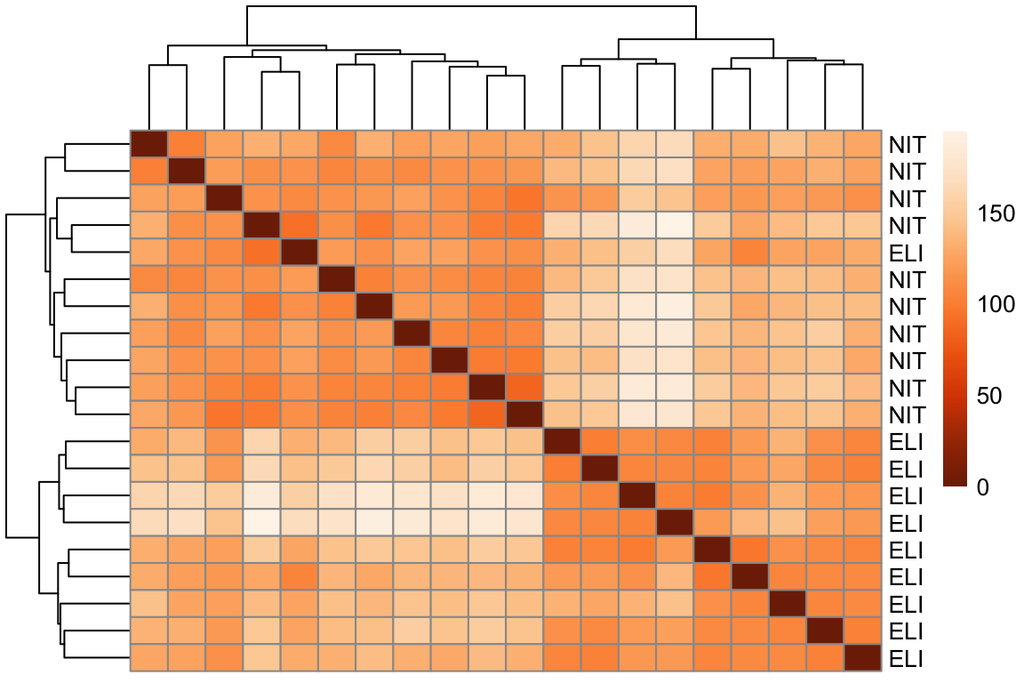

```r
# Carga de las librerías necesarias
library("pheatmap")
library("RColorBrewer")

# Definicón de sampleDists como matriz
sampleDistMatrix <- as.matrix(sampleDists)
rownames(sampleDistMatrix) <- paste(rld$Group, sep="-")
colnames(sampleDistMatrix) <- NULL

# Visualización del mapa de calor
colors <- colorRampPalette(rev(brewer.pal(9,"Oranges")))(255)
pheatmap(sampleDistMatrix,
         clustering_distance_rows = sampleDists,
         clustering_distance_cols = sampleDists,
         col = colors)
```

##### Gráfico PCA

Ahora vamos a visualizar de otra forma las distancias muestra a muestra a través de un análisis de componentes principales (PCA) utilizando los datos rlog. La variable *Group* se especifica por *intgroup* ya que es el grupo interesante para etiquetar las muestras.

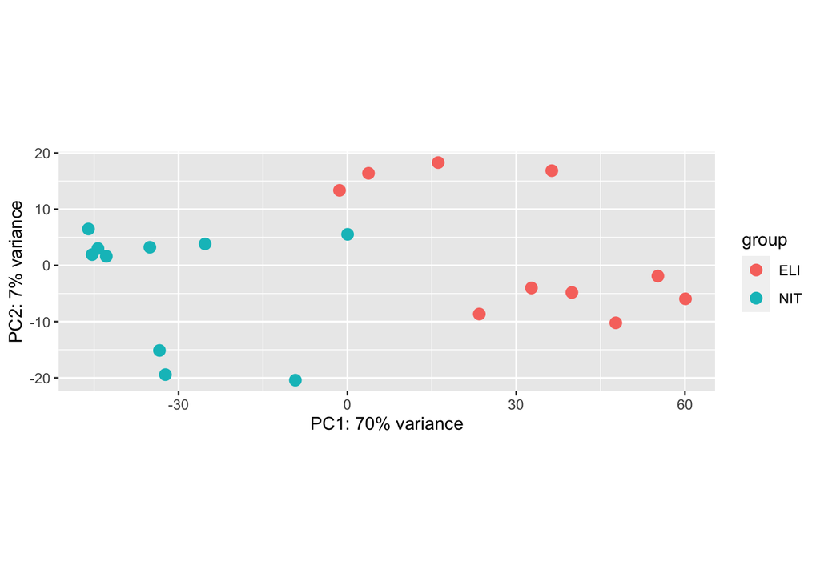

```r
# Visualización del gráfico PCA utilizando los datos rlog
plotPCA(rld, intgroup = c("Group"))
```

#### Análisis de expresión diferencial

##### Ejecución de la canalización de expresión diferencial

Vamos a ejecutar la canalización de expresión diferencial en los recuentos sin procesar con la función *DESeq()*.

```r
# Canalización de expresión diferencial
ddsMat_NIT_ELI <- DESeq(ddsMat_NIT_ELI, parallel =TRUE)
```

```
## -- replacing outliers and refitting for 322 genes
## -- DESeq argument 'minReplicatesForReplace' = 7
## -- original counts are preserved in counts(dds)
```

Dicha función devuelve un DESeqDataSet que contiene todos los parámetros ajustados dentro de él.

##### Creación de la tabla de resultados

```r
# Creación de la tabla de resultados
res <- results(ddsMat_NIT_ELI, contrast=c("Group","NIT","ELI"))
res
```

```
## log2 fold change (MLE): Group NIT vs ELI
## Wald test p-value: Group NIT vs ELI
## DataFrame with 56202 rows and 6 columns
##                          baseMean      log2FoldChange             lfcSE
##                         <numeric>           <numeric>         <numeric>
## ENSG00000223972  2.43557795878297   0.294828349842613 0.819075221753028
## ENSG00000227232  662.355559576073 -0.0249044875978755 0.217922075070982
## ENSG00000243485  1.21320988544358   0.741121452903529 0.820012486901555
## ENSG00000237613  1.58399723964576    1.99993812818412  1.03823825021881
## ENSG00000268020 0.914639344945851   0.722179170517074   1.2298869186369
## ...                           ...                 ...               ...
## ENSG00000198695   63678.126181884   0.571458116793175 0.542103807517716
## ENSG00000210194  26.0626415098931   0.833700506877101  1.00682495886945
## ENSG00000198727  436706.753460145   0.321517464964246 0.305744023623734
## ENSG00000210195 0.737774781092961    1.55631684137466  1.27895401325867
## ENSG00000210196  2.43561023925137   0.263484128050537 0.894523552818734
##                              stat             pvalue              padj
##                         <numeric>          <numeric>         <numeric>
## ENSG00000223972 0.359952714979713  0.718882494606093 0.858804941909521
## ENSG00000227232 -0.11428161919697  0.909014552786243 0.958955967703423
## ENSG00000243485 0.903792886988687  0.366105234149736 0.598036485450418
## ENSG00000237613  1.92628053123898 0.0540693550269273 0.181725094005652
## ENSG00000268020 0.587191521085105  0.557075086263294                NA
## ...                           ...                ...               ...
## ENSG00000198695   1.0541488712464  0.291814764213851 0.523378149181119
## ENSG00000210194 0.828049105788214  0.407642690518753 0.635385504524032
## ENSG00000198727  1.05159035049504  0.292987536859832 0.524595117226337
## ENSG00000210195  1.21686692816209  0.223654850413301                NA
## ENSG00000210196  0.29455247681324  0.768335770194889 0.886531788881736
```

Vamos a mostrar la información sobre el significado de las columnas del objeto *res*.

```r
# Información sobre las columnas del objeto res
mcols(res, use.names = TRUE)
```

```
## DataFrame with 6 rows and 2 columns
##                        type                               description
##                 <character>                               <character>
## baseMean       intermediate mean of normalized counts for all samples
## log2FoldChange      results  log2 fold change (MLE): Group NIT vs ELI
## lfcSE               results          standard error: Group NIT vs ELI
## stat                results          Wald statistic: Group NIT vs ELI
## pvalue              results       Wald test p-value: Group NIT vs ELI
## padj                results                      BH adjusted p-values
```

Finalmente, mostramos un resumen de la variable *res*.

```r
# Visualización resumen de res
summary(res)
```

```
##
## out of 44456 with nonzero total read count
## adjusted p-value < 0.1
## LFC > 0 (up)       : 2515, 5.7%
## LFC < 0 (down)     : 4445, 10%
## outliers [1]       : 0, 0%
## low counts [2]     : 13604, 31%
## (mean count < 1)
## [1] see 'cooksCutoff' argument of ?results
## [2] see 'independentFiltering' argument of ?results
```

#### Análisis de los resultados

##### Gráficación de los resultados

Vamos a visualizar los recuentos de un gen en particular con la función *plotCounts()* tomando como argumentos el DESeqDataSetFromMatrix, un nombre de gen y el grupo sobre el que trazar los recuentos.

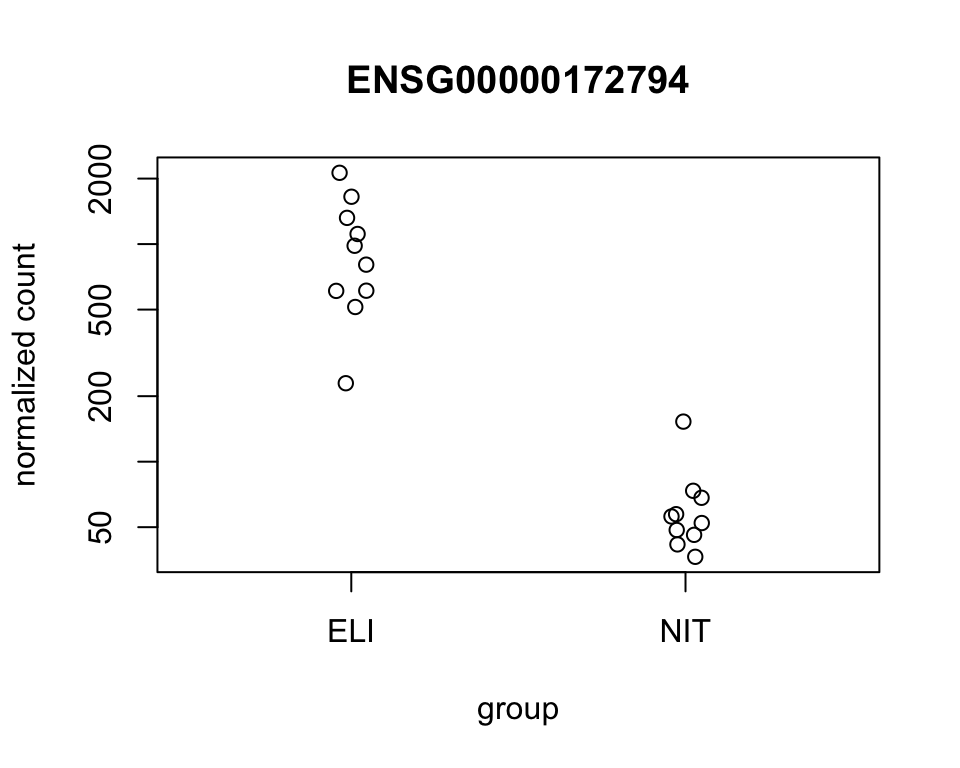

```r
# Selección del gen a mostrar
topGene <- rownames(res)[which.min(res$padj)]

# Representación del gráfico de los recuentos del gen
plotCounts(ddsMat_NIT_ELI, gene=topGene, intgroup=c("Group"))
```

##### Anotación y exportación de los resultados

La tabla de resultados obtenida hasta ahora, únicamente contiene los ID de los genes ENSEMBL. Para agregar más columnas informativas vamos a cargar los paquetes de anotación de Bioconductor para mapear varios esquemas de identificación entre sí.

```r
# Carga de las librerías necesarias
library("AnnotationDbi")
library("org.Hs.eg.db")

# Visualización de la lista de claves disponibles
columns(org.Hs.eg.db)
```

```
##  [1] "ACCNUM"       "ALIAS"        "ENSEMBL"      "ENSEMBLPROT"  "ENSEMBLTRANS"
##  [6] "ENTREZID"     "ENZYME"       "EVIDENCE"     "EVIDENCEALL"  "GENENAME"
## [11] "GO"           "GOALL"        "IPI"          "MAP"          "OMIM"
## [16] "ONTOLOGY"     "ONTOLOGYALL"  "PATH"         "PFAM"         "PMID"
## [21] "PROSITE"      "REFSEQ"       "SYMBOL"       "UCSCKG"       "UNIGENE"
## [26] "UNIPROT"
```

Con la función *mapIds* procedemos a agregar columnas a nuestra tabla de resultados. En concreto, vamos a añadir el símbolo del gen y la identificación de Entrez.

```r
# Agregación columna símbolo del gen
res$symbol <- mapIds(org.Hs.eg.db,
                     keys=row.names(res),
                     column="SYMBOL",
                     keytype="ENSEMBL",
                     multiVals="first")
# Agregación columna identificación de Entrez
res$entrez <- mapIds(org.Hs.eg.db,
                     keys=row.names(res),
                     column="ENTREZID",
                     keytype="ENSEMBL",
                     multiVals="first")
# Visualización de la nueva tabla de resultados ordenada por el p-valor
resOrdered <- res[order(res$pvalue),]
head(resOrdered, 3)
```

```
## log2 fold change (MLE): Group NIT vs ELI
## Wald test p-value: Group NIT vs ELI
## DataFrame with 3 rows and 8 columns
##                         baseMean    log2FoldChange             lfcSE
##                        <numeric>         <numeric>         <numeric>
## ENSG00000172794 529.152627642905 -3.98169701488659 0.332001768150874
## ENSG00000124256 408.784341524404 -4.64595187254982 0.393245603211196
## ENSG00000009790  1672.1086880203 -4.23516401884965 0.367081583022192
##                              stat               pvalue                 padj
##                         <numeric>            <numeric>            <numeric>
## ENSG00000172794 -11.9929994260668  3.8664637936515e-33 1.19307473280704e-28
## ENSG00000124256 -11.8143771592398 3.28977846846182e-32 5.07563471006631e-28
## ENSG00000009790 -11.5373917263335 8.54779209847002e-31 8.79197402608298e-27
##                      symbol      entrez
##                 <character> <character>
## ENSG00000172794       RAB37      326624
## ENSG00000124256        ZBP1       81030
## ENSG00000009790    TRAF3IP3       80342
```

Vamos a exportar la tabla de resultados en un archivo *.csv*.

```r
# Exportación de los resultados en fichero .csv
resOrderedDF <- as.data.frame(resOrdered)
write.csv(resOrderedDF, "./Results/results_NIT_ELI.csv")
```

Para obtener un fichero más sofisticado de los resultados, vamos a utilizar el paquete *ReportingTools* para generar automáticamente un documento HTML dinámico.

```r
# Carga de las librerías necesarias
library("ReportingTools")

# Creación del fichero HTML
htmlRep <- HTMLReport(shortName="Report_NIT_ELI", title="Report_NIT_ELI", reportDirectory="./Reports")
publish(resOrderedDF, htmlRep)
url <- finish(htmlRep)
browseURL(url)
```

### Comparación SFIvsELI

#### Creación del objeto DESeqDataSet

Vamos a construir el *DESeqDataSet* a partir de la matriz de conteo (countData) y la tabla de información de la muestra (colData) utilizando el comando *DESeqDataSetFromMatrix()* del paquete *DESeq2*.

```r
# Carga de las librerías necesarias
library("DESeq2")

# Creación del objeto DESeqDataSet
ddsMat_SFI_ELI <- DESeqDataSetFromMatrix(countData = countData_SFI_ELI, colData = colData_SFI_ELI, design = ~ Group)
```

#### Análisis exploratorio y visualización

##### Prefiltrado del conjunto de datos

La matriz de conteo con el *DESeqDataSet* contiene muchas filas con solo ceros y también muchas filas con solo unos pocos fragmentos en total. Con el fin de reducir el tamaño del objeto y aumentar la velocidad de nuestras funciones, vamos a eliminar las filas que tienen poca información sobre la cantidad de expresión génica. Para ello aplicamos la regla de filtrado más mínima que consiste en eliminar las filas del *DESeqDataSet* que no tienen recuentos, o que solamente tienen un único recuento en todas las muestras.

```r
# Número de filas iniciales
nrow(ddsMat_SFI_ELI)
```

```
## [1] 56202
```

```r
# Aplicación de filtrado mínimo
ddsMat_SFI_ELI_filtered <- ddsMat_SFI_ELI[rowSums(counts(ddsMat_SFI_ELI)) > 1,]

# Número de filas mantenidas después del filtrado
nrow(ddsMat_SFI_ELI_filtered)
```

```
## [1] 42122
```

Podemos observar que el tamaño del objeto ha disminuido.

##### Transformación de logaritmo regularizado o rlog

El paquete *DESeq2* ofrece la transformación rlog, la cual estabiliza la varianza a través de la media. Dicha transformación, a pesar de ser más sensible a los valores atípicos de conteo alto que VST (*Variance Stabilizing Transformation*), tiende a funcionar bien en conjuntos de datos pequeños (n<30) como es nuestro caso, donde tenemos un conjunto de datos de 20 muestras.

Así pues, vamos a aplicar dicha transformación a los datos de conteo, obteniendo un objeto DESeqTransform que se basa en la clase SummarizedExperiment.

```r
# Aplicación de la transformación rlog
rld <- rlog(ddsMat_SFI_ELI_filtered, blind = FALSE)

# Visualización de las 3 primera filas de los datos transformados con rlog
head(assay(rld), 3)
```

```
##                 GTEX.OXRP.0326.SM.33HBJ GTEX.11DXY.0426.SM.5H12R
## ENSG00000223972               1.0568659                0.7480615
## ENSG00000227232               9.5352695                9.3557189
## ENSG00000243485               0.5239438                0.1491532
##                 GTEX.13NZ8.0226.SM.5J2OK GTEX.12WSG.0226.SM.5EGIF
## ENSG00000223972                0.8898246                1.2853220
## ENSG00000227232                9.7901999                9.0229697
## ENSG00000243485                0.4052219                0.3484884
##                 GTEX.Y5V6.0526.SM.4VBRV GTEX.RM2N.0526.SM.2TF4N
## ENSG00000223972               1.1318514               1.2221004
## ENSG00000227232               8.8409872               8.9408429
## ENSG00000243485               0.5062568               0.6958428
##                 GTEX.12BJ1.0426.SM.5FQSO GTEX.139UW.0126.SM.5KM1B
## ENSG00000223972                0.9376661                1.1058774
## ENSG00000227232                8.9600757                9.0599902
## ENSG00000243485                0.4641610                0.1560059
##                 GTEX.SIU8.0626.SM.2XCDN GTEX.XMK1.0626.SM.4B65A
## ENSG00000223972                1.115886               1.7191137
## ENSG00000227232                9.432953               9.1695438
## ENSG00000243485                0.388926               0.3022892
##                 GTEX.111VG.0526.SM.5N9BW GTEX.YFC4.2626.SM.5P9FQ
## ENSG00000223972                0.9308574               0.8267284
## ENSG00000227232                9.0729539               9.6279446
## ENSG00000243485                0.3156704               0.2338557
##                 GTEX.13NZ9.1126.SM.5MR37 GTEX.14BMU.0226.SM.5S2QA
## ENSG00000223972                0.7250011                 1.113462
## ENSG00000227232                9.4777332                 9.070117
## ENSG00000243485                0.2637474                 0.157267
##                 GTEX.R55G.0726.SM.2TC6J GTEX.11XUK.0226.SM.5EQLW
## ENSG00000223972               1.6572288                0.7530162
## ENSG00000227232               8.9211055                8.9421956
## ENSG00000243485               0.5136535                0.1518255
##                 GTEX.ZYY3.1926.SM.5GZXS GTEX.14ABY.0926.SM.5Q5DY
## ENSG00000223972               1.5462352                0.8821971
## ENSG00000227232               9.9062571                9.3108728
## ENSG00000243485               0.3214319                0.3958641
##                 GTEX.13QJC.0826.SM.5RQKC GTEX.YJ89.0726.SM.5P9F7
## ENSG00000223972                0.7536529               1.1446560
## ENSG00000227232                9.6587609               9.6278033
## ENSG00000243485                0.3161284               0.2462331
```

A continuación se muestra el efecto de la transformación a través de un diagrama de dispersión de recuentos transformados de dos muestras (primera contra segunda).

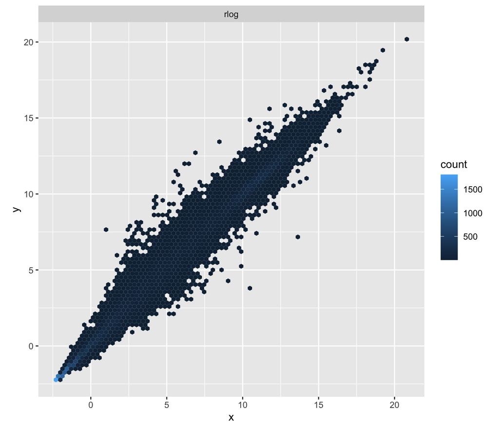

```r
# Carga de las librerías necesarias
library("dplyr")
library("ggplot2")

# Representación del gráfico de dispersión de recuentos transformados
ddsMat_SFI_ELI_filtered <- estimateSizeFactors(ddsMat_SFI_ELI_filtered)

df <- bind_rows(as_data_frame(assay(rld)[, 1:2]) %>% mutate(transformation = "rlog"))

colnames(df)[1:2] <- c("x", "y")

ggplot(df, aes(x = x, y = y)) + geom_hex(bins = 80) +
  coord_fixed() + facet_grid( . ~ transformation)
```

Podemos ver como rlog comprime las diferencias para los genes de recuento bajo (esquina inferior izquierda), para los cuales los datos proporcionan poca información sobre la expresión diferencial.

##### Distancia de muestras

Con el fin de evaluar la similitud general entre muestras, utilizamos la función *dist()* para calcular la distancia euclidiana entre ellas.

```r
# Cálculo de la distancia euclidiana entre muestras
sampleDists <- dist(t(assay(rld)))
head(sampleDists)
```

```
## [1] 125.6798 120.6834 153.0092 111.4947 109.1964 108.3608
```

Procedemos a visualizar las distancias en un mapa de calor con ayuda de la función *pheatmap()*, proporcionando como argumento *clustering_distance* la matriz de distancias *sampleDists*.

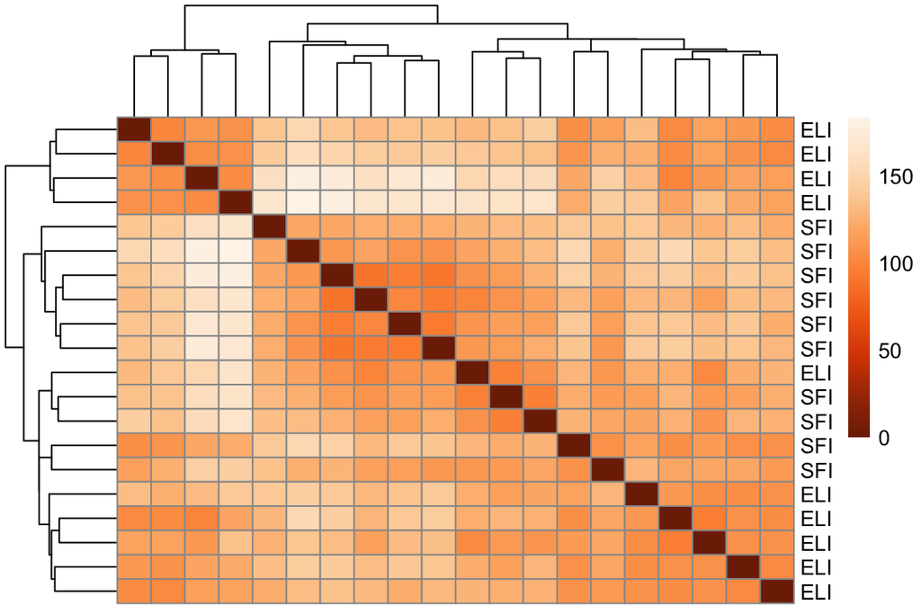

```r
# Carga de las librerías necesarias
library("pheatmap")
library("RColorBrewer")

# Definicón de sampleDists como matriz
sampleDistMatrix <- as.matrix(sampleDists)
rownames(sampleDistMatrix) <- paste(rld$Group, sep="-")
colnames(sampleDistMatrix) <- NULL

# Visualización del mapa de calor
colors <- colorRampPalette(rev(brewer.pal(9,"Oranges")))(255)
pheatmap(sampleDistMatrix,
         clustering_distance_rows = sampleDists,
         clustering_distance_cols = sampleDists,
         col = colors)
```

##### Gráfico PCA

Ahora vamos a visualizar de otra forma las distancias muestra a muestra a través de un análisis de componentes principales (PCA) utilizando los datos rlog. La variable *Group* se especifica por *intgroup* ya que es el grupo interesante para etiquetar las muestras.

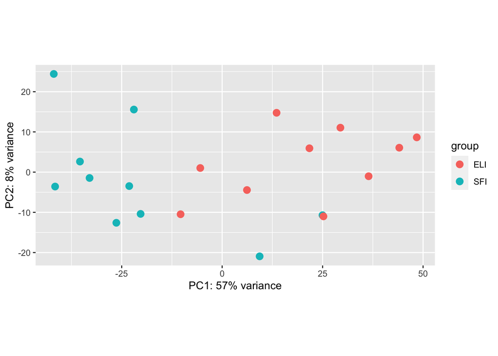

```r
# Visualización del gráfico PCA utilizando los datos rlog
plotPCA(rld, intgroup = c("Group"))
```

#### Análisis de expresión diferencial

##### Ejecución de la canalización de expresión diferencial

Vamos a ejecutar la canalización de expresión diferencial en los recuentos sin procesar con la función *DESeq()*.

```r
# Canalización de expresión diferencial
ddsMat_SFI_ELI <- DESeq(ddsMat_SFI_ELI, parallel =TRUE)
```

```
## -- replacing outliers and refitting for 380 genes
## -- DESeq argument 'minReplicatesForReplace' = 7
## -- original counts are preserved in counts(dds)
```

Dicha función devuelve un DESeqDataSet que contiene todos los parámetros ajustados dentro de él.

##### Creación de la tabla de resultados

```r
# Creación de la tabla de resultados
res <- results(ddsMat_SFI_ELI, contrast=c("Group","SFI","ELI"))
res
```

```
## log2 fold change (MLE): Group SFI vs ELI
## Wald test p-value: Group SFI vs ELI
## DataFrame with 56202 rows and 6 columns
##                          baseMean     log2FoldChange             lfcSE
##                         <numeric>          <numeric>         <numeric>
## ENSG00000223972  2.56041903988476  0.438884825272522 0.751564638508569
## ENSG00000227232  652.142116887341 -0.219771608317677 0.208918464190467
## ENSG00000243485  1.37663472743357   1.02170829910349 0.739768488510246
## ENSG00000237613  1.19549988775056   1.35819279380067  1.02078042390121
## ENSG00000268020 0.784773665551159  0.348470175869008  1.16398884143912
## ...                           ...                ...               ...
## ENSG00000198695  60731.4417985311  0.332794887146729 0.571774461852595
## ENSG00000210194  26.4711344084228  0.768053162245538 0.838083084955661
## ENSG00000198727  390746.837005474 -0.127849447943211 0.301569933296754
## ENSG00000210195 0.552803551192388  0.712450607283053  1.29923810541102
## ENSG00000210196  1.92557969950568 -0.557300066291381 0.848756889083245
##                               stat            pvalue              padj
##                          <numeric>         <numeric>         <numeric>
## ENSG00000223972  0.583961515463873 0.559246204410135 0.775481481294763
## ENSG00000227232  -1.05194918586667 0.292822863720774 0.560442498714495
## ENSG00000243485   1.38111897839961 0.167242381159512                NA
## ENSG00000237613   1.33054353512183 0.183339252381185                NA
## ENSG00000268020  0.299375873258519 0.764653268832051                NA
## ...                            ...               ...               ...
## ENSG00000198695  0.582038739660472 0.560540587035381 0.776106036021398
## ENSG00000210194  0.916440357803155 0.359435976015846 0.623162989637831
## ENSG00000198727 -0.423946268600335 0.671604999683049 0.844887227408805
## ENSG00000210195  0.548360307718702 0.583444525128495                NA
## ENSG00000210196 -0.656607414277755 0.511433380295778 0.744028202892599
```

Vamos a mostrar la información sobre el significado de las columnas del objeto *res*.

```r
# Información sobre las columnas del objeto res
mcols(res, use.names = TRUE)
```

```
## DataFrame with 6 rows and 2 columns
##                        type                               description
##                 <character>                               <character>
## baseMean       intermediate mean of normalized counts for all samples
## log2FoldChange      results  log2 fold change (MLE): Group SFI vs ELI
## lfcSE               results          standard error: Group SFI vs ELI
## stat                results          Wald statistic: Group SFI vs ELI
## pvalue              results       Wald test p-value: Group SFI vs ELI
## padj                results                      BH adjusted p-values
```

Finalmente, mostramos un resumen de la variable *res*.

```r
# Visualización resumen de res
summary(res)
```

```
##
## out of 45024 with nonzero total read count
## adjusted p-value < 0.1
## LFC > 0 (up)       : 1600, 3.6%
## LFC < 0 (down)     : 3001, 6.7%
## outliers [1]       : 0, 0%
## low counts [2]     : 16374, 36%
## (mean count < 2)
## [1] see 'cooksCutoff' argument of ?results
## [2] see 'independentFiltering' argument of ?results
```

#### Análisis de los resultados

##### Gráficación de los resultados

Vamos a visualizar los recuentos de un gen en particular con la función *plotCounts()* tomando como argumentos el DESeqDataSetFromMatrix, un nombre de gen y el grupo sobre el que trazar los recuentos.

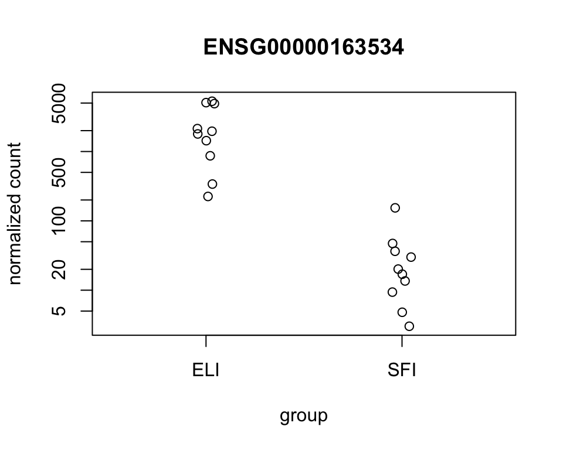

```r
# Selección del gen a mostrar
topGene <- rownames(res)[which.min(res$padj)]

# Representación del gráfico de los recuentos del gen
plotCounts(ddsMat_SFI_ELI, gene=topGene, intgroup=c("Group"))
```

##### Anotación y exportación de los resultados

La tabla de resultados obtenida hasta ahora, únicamente contiene los ID de los genes ENSEMBL. Para agregar más columnas informativas vamos a cargar los paquetes de anotación de Bioconductor para mapear varios esquemas de identificación entre sí.

```r
# Carga de las librerías necesarias
library("AnnotationDbi")
library("org.Hs.eg.db")

# Visualización de la lista de claves disponibles
columns(org.Hs.eg.db)
```

```
##  [1] "ACCNUM"       "ALIAS"        "ENSEMBL"      "ENSEMBLPROT"  "ENSEMBLTRANS"
##  [6] "ENTREZID"     "ENZYME"       "EVIDENCE"     "EVIDENCEALL"  "GENENAME"
## [11] "GO"           "GOALL"        "IPI"          "MAP"          "OMIM"
## [16] "ONTOLOGY"     "ONTOLOGYALL"  "PATH"         "PFAM"         "PMID"
## [21] "PROSITE"      "REFSEQ"       "SYMBOL"       "UCSCKG"       "UNIGENE"
## [26] "UNIPROT"
```

Con la función *mapIds* procedemos a agregar columnas a nuestra tabla de resultados. En concreto, vamos a añadir el símbolo del gen y la identificación de Entrez.

```r
# Agregación columna símbolo del gen
res$symbol <- mapIds(org.Hs.eg.db,
                     keys=row.names(res),
                     column="SYMBOL",
                     keytype="ENSEMBL",
                     multiVals="first")
# Agregación columna identificación de Entrez
res$entrez <- mapIds(org.Hs.eg.db,
                     keys=row.names(res),
                     column="ENTREZID",
                     keytype="ENSEMBL",
                     multiVals="first")
# Visualización de la nueva tabla de resultados ordenada por el p-valor
resOrdered <- res[order(res$pvalue),]
head(resOrdered, 3)
```

```
## log2 fold change (MLE): Group SFI vs ELI
## Wald test p-value: Group SFI vs ELI
## DataFrame with 3 rows and 8 columns
##                         baseMean    log2FoldChange             lfcSE
##                        <numeric>         <numeric>         <numeric>
## ENSG00000163534 1218.39924447239 -6.19085709738766  0.59804897428517
## ENSG00000175857 247.641256628419 -4.21924911362913 0.409120594633571
## ENSG00000167483 1138.37493650144 -5.25907868884278 0.545603420676993
##                              stat               pvalue                 padj
##                         <numeric>            <numeric>            <numeric>
## ENSG00000163534 -10.3517560661105 4.10879311413567e-25 8.82109189118532e-21
## ENSG00000175857 -10.3129716982546 6.15675581307647e-25 8.82109189118532e-21
## ENSG00000167483 -9.63901341072467  5.4711259652504e-22 5.22583715114168e-18
##                      symbol      entrez
##                 <character> <character>
## ENSG00000163534       FCRL1      115350
## ENSG00000175857        GAPT      202309
## ENSG00000167483      NIBAN3      199786
```

Vamos a exportar la tabla de resultados en un archivo *.csv*.

```r
# Exportación de los resultados en fichero .csv
resOrderedDF <- as.data.frame(resOrdered)
write.csv(resOrderedDF, "./Results/results_SFI_ELI.csv")
```

Para obtener un fichero más sofisticado de los resultados, vamos a utilizar el paquete *ReportingTools* para generar automáticamente un documento HTML dinámico.

```r
# Carga de las librerías necesarias
library("ReportingTools")

# Creación del fichero HTML
htmlRep <- HTMLReport(shortName="Report_SFI_ELI", title="Report_SFI_ELI", reportDirectory="./Reports")
publish(resOrderedDF, htmlRep)
url <- finish(htmlRep)
browseURL(url)
```

## Resultados

Los resultados obtenidos se han ido mostrando y analizando durante la ejecución de los distintos apartados. Particularmente, en la sección “Análisis de resultados” de cada comparación se ha exportado un fichero *.csv* y otro *html* con los resultados del análisis.

[^1]: https://github.com/carlariera/RNA-seq